# Methods to Map Peak to Genes(Day 2)

# Methods to Map Peak to Genes(Day 2)

### Learning outcomes

- You will learn several types of peak to gene mapping methods

# Setting Up the framework

Once you know what peaks change the next step is to tie this data to gene expression or gene regulation. For example if you have a transcription factor peak increase in the promoter of gene_a and that gene_a increases in expression then you can associate that transcription factor with the up regulation of gene_a. Conversely, if that same transcription factor increasing in binding at gene_b and gene_b decreases in expression then that TF can be associated with down-regulation of gene_b.

✎ Assume you have count data from a ChIP-seq of TF peak case and control as well as gene expression values between case and control. What are the steps in identifying which genes the TF regulates between case and control? ✎

> 1. Differential analysis of the Peak regions to determine where the TF gains binding and loses binding in comparison to the WT samples.
> 2. Differential analysis of the gene expression to determine which genes are unregulated and down-regulated in comparison to the WT samples.
> 3. Map the peaks to genes. Peaks that change that are mapped to genes that change can be associated with regulation of those genes

## Interpretation framework

✎Fill out this table to interpret peaks that change that are mapped to genes that change✎

|  | Peak Gained | Peak Lost |
| --- | --- | --- |
| Gene Up-regulated |  |  |
| Gene Down-regulated |  |  |

\

# Peak mapping methods

## Nearest gene

The naive method in mapping peaks to genes is simply mapping it to its nearest gene. You will know the genomic location of your peaks and you can use the TSS of each gene. Using those coordinates you can map peaks to the nearest gene. Luckily for us, there is a well documented R package that will do this for you.

The `ChIPseeker` package has many functions to work with chromatin data. In this course we will go through how to use the `annotatePeaks()` function in which you pass in an object that holds the peak positions (Chr, Start, Stop), and you specify the genome (mouse, human, fly) and it will output a nearest gene for each peak as well as some information about the peak in relation to the gene.

Before we run the code, let’s check out the default options of `annotatePeaks()`

```r
library(tidyverse)
```

```r
?annotatePeak()
```

```r
# get path to peak bed file
sample_file = "../workshop_data/output/down_peaks.bed"
```

```r
# run annotatePeak()
annot = annotatePeak(sample_file, TxDb=TxDb.Mmusculus.UCSC.mm10.knownGene, tssRegion=c(-1000, 1000), verbose=FALSE)
```

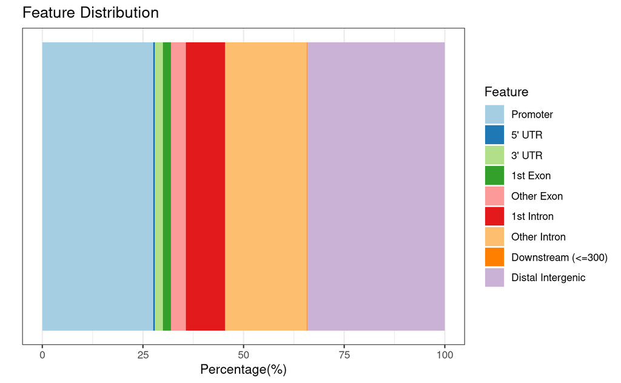

```r
# plot
plotAnnoBar(annot)
```

[figure not shown]

You can also do this with multiple bed files using the `lapply()` function,

```r
sample_files
```

```
[[1]]
[1] "../workshop_data/output//down_peaks.bed"

[[2]]
[1] "../workshop_data/output//up_peaks.bed"
```

```r
names(sample_files) <- c("Early", "Late")
sample_files
```

```
$Early
[1] "../workshop_data/output//down_peaks.bed"

$Late
[1] "../workshop_data/output//up_peaks.bed"
```

```r
# run annotatePeak()
zic_anno = lapply(sample_files, annotatePeak, TxDb=TxDb.Mmusculus.UCSC.mm10.knownGene, tssRegion=c(-1000, 1000), verbose=FALSE)
```

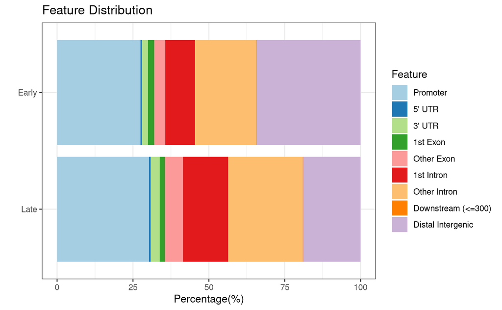

```r
# plot
plotAnnoBar(zic_anno)
```

✎ Brainstorm some questions you can explore with the data with peaks mapped to nearest gene✎

> **1.** What are the distribution of peaks mapped to genes that are expressed? or deferentially expressed?

### Explore the data

```r
str( zic_anno$Early@anno)
```

```
Formal class 'GRanges' [package "GenomicRanges"] with 7 slots
  ..@ seqnames       :Formal class 'Rle' [package "S4Vectors"] with 4 slots
  .. .. ..@ values         : Factor w/ 21 levels "chr1","chr10",..: 1 2 3 4 5 6 7 8 9 10 ...
  .. .. ..@ lengths        : int [1:21] 1042 747 1103 687 676 724 677 500 693 498 ...
  .. .. ..@ elementMetadata: NULL
  .. .. ..@ metadata       : list()
  ..@ ranges         :Formal class 'IRanges' [package "IRanges"] with 6 slots
  .. .. ..@ start          : int [1:15731] 3552537 5023133 5082842 5916575 6214298 6483438 6510344 9648785 10039433 10596349 ...
  .. .. ..@ width          : int [1:15731] 352 447 862 333 1044 363 529 904 969 797 ...
  .. .. ..@ NAMES          : NULL
  .. .. ..@ elementType    : chr "ANY"
  .. .. ..@ elementMetadata: NULL
  .. .. ..@ metadata       : list()
  ..@ strand         :Formal class 'Rle' [package "S4Vectors"] with 4 slots
  .. .. ..@ values         : Factor w/ 3 levels "+","-","*": 3
  .. .. ..@ lengths        : int 15731
  .. .. ..@ elementMetadata: NULL
  .. .. ..@ metadata       : list()
  ..@ seqinfo        :Formal class 'Seqinfo' [package "GenomeInfoDb"] with 4 slots
  .. .. ..@ seqnames   : chr [1:21] "chr1" "chr10" "chr11" "chr12" ...
  .. .. ..@ seqlengths : int [1:21] 195471971 130694993 122082543 120129022 120421639 124902244 104043685 98207768 94987271 90702639 ...
  .. .. ..@ is_circular: logi [1:21] NA NA NA NA NA NA ...
  .. .. ..@ genome     : chr [1:21] "mm10" "mm10" "mm10" "mm10" ...
  ..@ elementMetadata:Formal class 'DFrame' [package "S4Vectors"] with 6 slots
  .. .. ..@ rownames       : NULL
  .. .. ..@ nrows          : int 15731
  .. .. ..@ elementType    : chr "ANY"
  .. .. ..@ elementMetadata: NULL
  .. .. ..@ metadata       : list()
  .. .. ..@ listData       :List of 9
  .. .. .. ..$ annotation   : chr [1:15731] "Intron (ENSMUST00000070533.4/497097, intron 1 of 2)" "Intron (ENSMUST00000118000.7/58175, intron 1 of 5)" "Promoter" "Promoter" ...
  .. .. .. ..$ geneChr      : int [1:15731] 1 1 1 1 1 1 1 1 1 1 ...
  .. .. .. ..$ geneStart    : int [1:15731] 3214482 4909576 5083080 5913707 6214645 6487231 6487331 9601018 10039767 10472475 ...
  .. .. .. ..$ geneEnd      : int [1:15731] 3671498 5019539 5162529 5917398 6276648 6860934 6860940 9631175 10058872 10477823 ...
  .. .. .. ..$ geneLength   : int [1:15731] 457017 109964 79450 3692 62004 373704 373610 30158 19106 5349 ...
  .. .. .. ..$ geneStrand   : int [1:15731] 2 2 1 2 1 1 1 2 1 2 ...
  .. .. .. ..$ geneId       : chr [1:15731] "497097" "58175" "108664" "226304" ...
  .. .. .. ..$ transcriptId : chr [1:15731] "ENSMUST00000070533.4" "ENSMUST00000002533.14" "ENSMUST00000044369.12" "ENSMUST00000044180.4" ...
  .. .. .. ..$ distanceToTSS: num [1:15731] 118610 -3594 0 491 0 ...
  ..@ elementType    : chr "ANY"
  ..@ metadata       : list()
```

```r
early_annotations = zic_anno$Early@anno %>% as.data.frame()
head(early_annotations)
```

|  | seqnames | start | end | width | strand | annotation | geneChr | geneStart | geneEnd | geneLength | geneStrand | geneId | transcriptId | distanceToTSS |
| --- | --- | --- | --- | --- | --- | --- | --- | --- | --- | --- | --- | --- | --- | --- |
| 1 | chr1 | 3552537 | 3552888 | 352 | * | Intron (ENSMUST00000070533.4/497097, intron 1 of 2) | 1 | 3214482 | 3671498 | 457017 | 2 | 497097 | ENSMUST00000070533.4 | 118610 |
| 2 | chr1 | 5023133 | 5023579 | 447 | * | Intron (ENSMUST00000118000.7/58175, intron 1 of 5) | 1 | 4909576 | 5019539 | 109964 | 2 | 58175 | ENSMUST00000002533.14 | -3594 |
| 3 | chr1 | 5082842 | 5083703 | 862 | * | Promoter | 1 | 5083080 | 5162529 | 79450 | 1 | 108664 | ENSMUST00000044369.12 | 0 |
| 4 | chr1 | 5916575 | 5916907 | 333 | * | Promoter | 1 | 5913707 | 5917398 | 3692 | 2 | 226304 | ENSMUST00000044180.4 | 491 |
| 5 | chr1 | 6214298 | 6215341 | 1044 | * | Promoter | 1 | 6214645 | 6276648 | 62004 | 1 | 12421 | ENSMUST00000027040.12 | 0 |
| 6 | chr1 | 6483438 | 6483800 | 363 | * | Distal Intergenic | 1 | 6487231 | 6860934 | 373704 | 1 | 240690 | ENSMUST00000140079.7 | -3431 |

```r
NA
```

```r
# BiocManager::install("EnsDb.Mmusculus.v79")

library(EnsDb.Mmusculus.v79)
```

```r
edb <- EnsDb.Mmusculus.v79
tx <- transcripts(edb, columns=c("tx_id", "gene_id", "gene_name"))
mapping <- data.frame(tx_id=tx$tx_id, SYMBOL=tx$gene_name)

head(mapping)
```

|  | tx_id | SYMBOL |
| --- | --- | --- |
| 1 | ENSMUST00000193812 | RP23-271O17.1 |
| 2 | ENSMUST00000082908 | Gm26206 |
| 3 | ENSMUST00000162897 | Xkr4 |
| 4 | ENSMUST00000159265 | Xkr4 |
| 5 | ENSMUST00000070533 | Xkr4 |
| 6 | ENSMUST00000192857 | RP23-317L18.1 |

```r
# adding gene symbols
early_annotations = early_annotations %>%
  mutate(tx_id = gsub("\\..*","",transcriptId)) %>%
  left_join(mapping, by = "tx_id" )

head(early_annotations)
```

|  | seqnames | start | end | width | strand | annotation | geneChr | geneStart | geneEnd | geneLength | geneStrand | geneId | transcriptId | distanceToTSS | tx_id | SYMBOL |
| --- | --- | --- | --- | --- | --- | --- | --- | --- | --- | --- | --- | --- | --- | --- | --- | --- |
| 1 | chr1 | 3552537 | 3552888 | 352 | * | Intron (ENSMUST00000070533.4/497097, intron 1 of 2) | 1 | 3214482 | 3671498 | 457017 | 2 | 497097 | ENSMUST00000070533.4 | 118610 | ENSMUST00000070533 | Xkr4 |
| 2 | chr1 | 5023133 | 5023579 | 447 | * | Intron (ENSMUST00000118000.7/58175, intron 1 of 5) | 1 | 4909576 | 5019539 | 109964 | 2 | 58175 | ENSMUST00000002533.14 | -3594 | ENSMUST00000002533 | Rgs20 |
| 3 | chr1 | 5082842 | 5083703 | 862 | * | Promoter | 1 | 5083080 | 5162529 | 79450 | 1 | 108664 | ENSMUST00000044369.12 | 0 | ENSMUST00000044369 | Atp6v1h |
| 4 | chr1 | 5916575 | 5916907 | 333 | * | Promoter | 1 | 5913707 | 5917398 | 3692 | 2 | 226304 | ENSMUST00000044180.4 | 491 | ENSMUST00000044180 | Npbwr1 |
| 5 | chr1 | 6214298 | 6215341 | 1044 | * | Promoter | 1 | 6214645 | 6276648 | 62004 | 1 | 12421 | ENSMUST00000027040.12 | 0 | ENSMUST00000027040 | Rb1cc1 |
| 6 | chr1 | 6483438 | 6483800 | 363 | * | Distal Intergenic | 1 | 6487231 | 6860934 | 373704 | 1 | 240690 | ENSMUST00000140079.7 | -3431 | ENSMUST00000140079 | St18 |

```r
diff_exp = read_csv("../workshop_data/p60vp7.csv")
head(diff_exp)
```

| baseMean | log2FoldChange | lfcSE | stat | pvalue | padj | sig | SYMBOL |
| --- | --- | --- | --- | --- | --- | --- | --- |
| 59.13212 | -1.1538739 | 0.3046247 | -3.787853 | 1.519545e-04 | 3.222185e-04 | not sig | 0610005C13Rik |
| 622.51208 | 0.2344251 | 0.1525720 | 1.536488 | 1.244187e-01 | 1.643227e-01 | not sig | 0610009B22Rik |
| 386.34174 | -1.2328316 | 0.1686906 | -7.308242 | 2.706600e-13 | 1.225020e-12 | not sig | 0610009E02Rik |
| 91.81511 | -0.1754108 | 0.2577577 | -0.680526 | 4.961715e-01 | 5.579991e-01 | not sig | 0610009L18Rik |
| 2261.45229 | -0.6490978 | 0.1885462 | -3.442645 | 5.760543e-04 | 1.131084e-03 | not sig | 0610010F05Rik |
| 985.01318 | -0.4461252 | 0.1750966 | -2.547880 | 1.083797e-02 | 1.755849e-02 | not sig | 0610012G03Rik |

```r
early_annotations = early_annotations %>%
  left_join(diff_exp, by = "SYMBOL")

head(early_annotations)
```

|  | seqnames | start | end | width | strand | annotation | geneChr | geneStart | geneEnd | geneLength | geneStrand | geneId | transcriptId | distanceToTSS | tx_id | SYMBOL | baseMean | log2FoldChange | lfcSE | stat | pvalue | padj | sig |
| --- | --- | --- | --- | --- | --- | --- | --- | --- | --- | --- | --- | --- | --- | --- | --- | --- | --- | --- | --- | --- | --- | --- | --- |
| 1 | chr1 | 3552537 | 3552888 | 352 | * | Intron (ENSMUST00000070533.4/497097, intron 1 of 2) | 1 | 3214482 | 3671498 | 457017 | 2 | 497097 | ENSMUST00000070533.4 | 118610 | ENSMUST00000070533 | Xkr4 | 658.93293 | -0.327928046 | 0.2647924 | -1.23843439 | 2.155550e-01 | 2.693235e-01 | not sig |
| 2 | chr1 | 5023133 | 5023579 | 447 | * | Intron (ENSMUST00000118000.7/58175, intron 1 of 5) | 1 | 4909576 | 5019539 | 109964 | 2 | 58175 | ENSMUST00000002533.14 | -3594 | ENSMUST00000002533 | Rgs20 | 594.32323 | -0.253677453 | 0.1509113 | -1.68097112 | 9.276853e-02 | 1.256840e-01 | not sig |
| 3 | chr1 | 5082842 | 5083703 | 862 | * | Promoter | 1 | 5083080 | 5162529 | 79450 | 1 | 108664 | ENSMUST00000044369.12 | 0 | ENSMUST00000044369 | Atp6v1h | 4535.55890 | 0.470408297 | 0.1055102 | 4.45841722 | 8.256707e-06 | 2.020668e-05 | not sig |
| 4 | chr1 | 5916575 | 5916907 | 333 | * | Promoter | 1 | 5913707 | 5917398 | 3692 | 2 | 226304 | ENSMUST00000044180.4 | 491 | ENSMUST00000044180 | Npbwr1 | 20.20508 | -6.097361163 | 1.1040268 | -5.52283789 | 3.335675e-08 | 1.025532e-07 | DOWN |
| 5 | chr1 | 6214298 | 6215341 | 1044 | * | Promoter | 1 | 6214645 | 6276648 | 62004 | 1 | 12421 | ENSMUST00000027040.12 | 0 | ENSMUST00000027040 | Rb1cc1 | 3200.11573 | 0.709478869 | 0.1784748 | 3.97523324 | 7.031031e-05 | 1.554147e-04 | not sig |
| 6 | chr1 | 6483438 | 6483800 | 363 | * | Distal Intergenic | 1 | 6487231 | 6860934 | 373704 | 1 | 240690 | ENSMUST00000140079.7 | -3431 | ENSMUST00000140079 | St18 | 4348.91030 | 0.008728293 | 0.1687070 | 0.05173639 | 9.587387e-01 | 9.657662e-01 | not sig |

### lets ask some questions

Are early peaks near early genes?

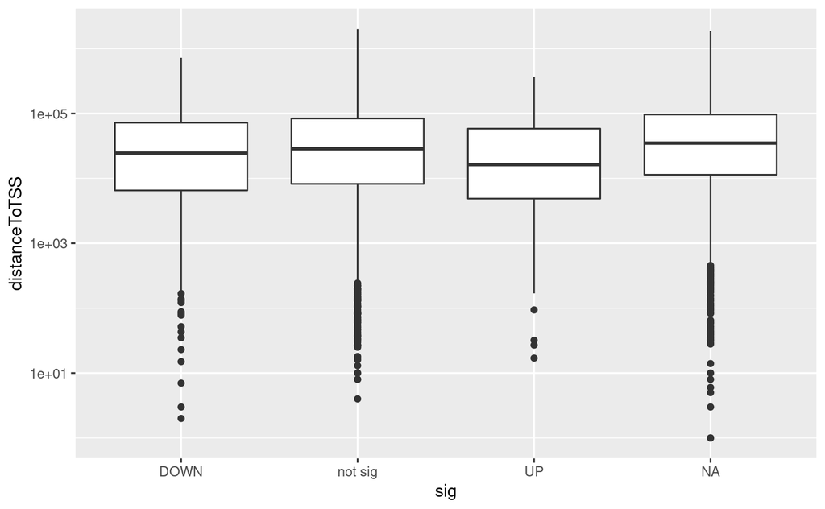

```r
early_annotations %>%
  dplyr::select(seqnames, start, end, SYMBOL, distanceToTSS, sig ) %>%
  ggplot(aes(y = distanceToTSS, x = sig )) +
  geom_boxplot() +
  scale_y_log10()
```

What kids of genes are early peaks near?

```r
dotplot(go_bp)
```

[output not shown]

## Using 3D Chromatin Information

So with the nearest gene methods, you may get peaks that map kilobases away from the gene. How can we be sure that that mapping is biologically relevant? Now, we can use 3D chromatin data to map genes to their enhancers and use this link as a means of mapping distal peaks to genes.

Lets work through how we would do this, we want the data to look something like this:

| loop | anchor1 | anchor2 | gene | intersecting peaks |
| --- | --- | --- | --- | --- |
| loop1 | chr1:1000-2000 | chr1:4000-5000 | geneA | chr1:1150-1250 chr1:1500-1600 chr1:1750-1950 chr1:4200-4300 chr1:4500-4700 |
| loop2 | chr1:6000-7000 | chr1:9000-10000 | geneB | chr1:6600-7000 chr1:9100-9200 chr1:9300-9400 chr1:9450-9900 |

What to we need to do

1. **map loops to genes**
   1. treat the loop anchors like peaks
   2. map them to nearest gene using `annotatePeaks()`
   3. filter loops for at list one of the anchors mapping to the promoter (`distanceToTSS =0`)
2. **get peak intersection with loop anchors.** Use `bedtools` to get the intersection of peaks in anchors

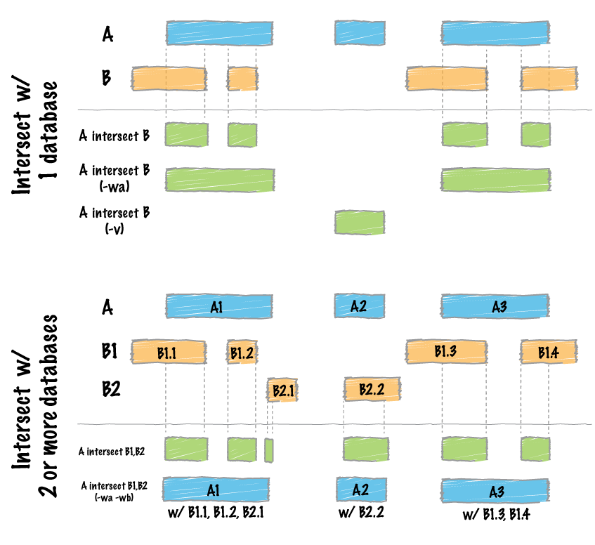

3. **map the peaks to gene via the loops.** For this we will just need to combine and reformat the data

   | loop | anchors | peaks | gene |
   | --- | --- | --- | --- |
   | loop1 | chr1:1000-2000 | chr1:1150-1250 |  |
   | loop1 | chr1:1000-2000 | chr1:1500-1600 |  |
   | loop1 | chr1:1000-2000 | chr1:1750-1950 |  |
   | loop1 | chr1:4000-5000 | chr1:4200-4300 | geneA |
   | loop1 | chr1:4000-5000 | chr1:4500-4700 | geneA |

   LETS CODE IT:

### anchor peak instersection

[output not shown]

```bash
bedtools intersect -a ../workshop_data/output/loops.bed -b ../workshop_data/output/down_peaks.bed
```

```bash
bedtools intersect -wa -wb -a ../workshop_data/output/loops.bed -b ../workshop_data/output/down_peaks.bed > ../workshop_data/output/early_peak_intersections.bed

bedtools intersect -wa -wb -a ../workshop_data/output/loops.bed -b ../workshop_data/output/up_peaks.bed > ../workshop_data/output/late_peak_intersections.bed
```

### anchor gene mapping

```r
anchor_annot = annotatePeak("../workshop_data/output/loops.bed",
                            TxDb=TxDb.Mmusculus.UCSC.mm10.knownGene,
                            tssRegion=c(-1000, 1000),
                            verbose=TRUE)
```

```
>> loading peak file...              2022-08-18 03:29:59 PM
>> preparing features information...         2022-08-18 03:30:00 PM
>> identifying nearest features...       2022-08-18 03:30:01 PM
>> calculating distance from peak to TSS...  2022-08-18 03:30:02 PM
>> assigning genomic annotation...       2022-08-18 03:30:03 PM
>> assigning chromosome lengths          2022-08-18 03:30:06 PM
>> done...                   2022-08-18 03:30:07 PM
```

[figure not shown]

[output not shown]

```r
# add the gene loops to zic intersections
early_peak_loop = read_tsv("../workshop_data/output/early_peak_intersections.bed", col_names = F)
head(early_peak_loop)
```

| X1 | X2 | X3 | X4 | X5 | X6 |
| --- | --- | --- | --- | --- | --- |
| chr1 | 6210000 | 6220000 | chr1 | 6214297 | 6215341 |
| chr1 | 16610000 | 16620000 | chr1 | 16618556 | 16619769 |
| chr1 | 22630000 | 22640000 | chr1 | 22631978 | 22633002 |
| chr1 | 22640000 | 22650000 | chr1 | 22640533 | 22641102 |
| chr1 | 22800000 | 22810000 | chr1 | 22805302 | 22806725 |
| chr1 | 22800000 | 22810000 | chr1 | 22805302 | 22806725 |

```r
early_peak_loop = early_peak_loop %>%
  dplyr::mutate(anchor_name = paste0(X1, ":", X2, "-", X3),
                peak_name = paste0(X4, ":", X5, "-", X6)) %>%
  dplyr::select(anchor_name, peak_name)

head(early_peak_loop)
```

| anchor_name | peak_name |
| --- | --- |
| chr1:6210000-6220000 | chr1:6214297-6215341 |
| chr1:16610000-16620000 | chr1:16618556-16619769 |
| chr1:22630000-22640000 | chr1:22631978-22633002 |
| chr1:22640000-22650000 | chr1:22640533-22641102 |
| chr1:22800000-22810000 | chr1:22805302-22806725 |
| chr1:22800000-22810000 | chr1:22805302-22806725 |

```r
early_peak_loop = early_peak_loop %>%
  left_join(loop_data) %>%
  dplyr::select(peak_name, loop_id)
head(early_peak_loop)
```

| peak_name | loop_id |
| --- | --- |
| chr1:6214297-6215341 | loop1 |
| chr1:16618556-16619769 | loop26 |
| chr1:22631978-22633002 | loop32 |
| chr1:22640533-22641102 | loop33 |
| chr1:22805302-22806725 | loop36 |
| chr1:22805302-22806725 | loop37 |

[output not shown]

Give it a try:

### lets ask some questions

First lets add in the gene expression